# Metacognitive uncertainty in Correct and Error trials across the post decisional response window

<sup>1</sup>Center of Functionally Integrative Neuroscience (CFIN), Department of Clinical Medicine, Aarhus University

<sup>2</sup>Institute of NeuroScience, Université catholique de Louvain, Brussels (Belgium)

<sup>3</sup>Cambridge Psychiatry, University of Cambridge, United Kingdom

*Equal contributions

Corresponding author: Jesper Fischer Ehmsen (jesperfischer@cfin.au.dk)

This preregistration consists of three parts. The first two parts provide justification for the experimental design and the computational model, respectively. The third part is the main preregistration.

1. **Considerations of models and empirical data from metacognitive perceptual decision-making tasks**
2. **Outline of our computational model**
3. **Design, methods, hypotheses, and sample size considerations of the current study.**

Each part is maintained in a separate document; this document includes all three.

# Part 1: Perceptual Decision-Making with Confidence

Metacognition, the ability to reflect on one’s own cognitive processes, is commonly studied through confidence ratings in decision-making tasks. In this document we highlight empirical findings and experimental considerations relevant to perceptual decision making with confidence ratings.

Three main aspects characterize the relationship between confidence ratings and choices.

1. Confidence ratings reflect a subjective probability of being correct or a form of self-consistency that incorporates response biases rather than purely objective performance (Caziot and Mamassian 2021; Sánchez-Fuenzalida et al. 2025; Mihali et al. 2023; Navajas et al. 2017).
2. Confidence judgments tend to underestimate relative to first-order accuracy (i.e., 90% accuracy might produce 80% confidence) (Shekhar and Rahnev 2021).
3. Metacognition and error-monitoring are functionally related systems, being confident about an error is a form of error-monitoring (Yeung and Summerfield 2012; Stephen M. Fleming and Daw 2017; Öztel and Balcı 2024).

## Models of perceptual decision making and metacognition

Computational models of metacognition typically fall into two categories: **static models** based on Signal Detection Theory (SDT) and **dynamic models** based on evidence accumulation (EA).

Static models describe choice and confidence as originating from a static process of acquiring a fixed sample of evidence on each trial. Confidence ratings are then assumed to be computed from this evidence alone or in conjunction with additional independent information.

Dynamic models additionally account for response times by assuming that evidence accumulates over time. When a decision boundary is reached (enough evidence has been collected), a choice is made. Confidence ratings are then thought to be generated by additional evidence accumulation in the post-decisional time window.

Both approaches can be understood as (approximately) optimal solutions to partially observable Markov decision processes under different assumptions. In most perceptual decision making tasks these two types of models are not mutually exclusive.

### Patterns of Confidence ratings

Regardless of theoretical framework, a good metacognition model must be able to capture several empirical patterns observed in the literature.

1. **Performance increases with stimulus intensity**: Higher stimulus intensity yields higher accuracy
2. **Confidence curves shift in tandem with first-order choice curves**: As the psychometric function governing the choice probability, shifts from unbiased (threshold at 0) so does the confidence curves. The lowest confidence ratings for correct trials are at the stimulus value of the threshold (Caziot and Mamassian 2021; Sánchez-Fuenzalida et al. 2025; Mihali et al. 2023).
3. **Confidence increases with stimulus intensity**: Higher stimulus intensities yield higher confidence ratings (conditional on accuracy, see below) (Hangya et al. 2016; Sanders et al. 2016)
4. **Confidence varies with accuracy**: The relationship between confidence and stimulus intensity depends on response correctness, with correct trials showing on average higher confidence than incorrect trials. (Hangya et al. 2016; Sanders et al. 2016).
   1. **“Folded-X” pattern**: Confidence sometimes increases with stimulus intensity for correct responses but decreases (or plateaus) for errors. This pattern is considered a signature of metacognition (Hangya et al. 2016; Sanders et al. 2016).
   2. **“Double-increase” pattern**: Confidence increases with stimulus intensity for both correct and incorrect responses

Recent work suggest that these two patterns of confidence, could potentially arises from different experimental manipulations (Xue et al. 2026; Fung et al. 2025):

- **Folded-X**: Emerges when manipulating decision-relevant stimulus properties (e.g., coherence in RDM).
- **Double-increase**: Occurs when manipulating auxiliary difficulty markers (e.g., stimulus visibility).

These studies investigating patterns 4a and 4b use a confidence scale that ranges from guessing to certain. This severely limits the information carried by the incorrect side of the confidence curve, as we argue in the next section. Furthermore, if participants cannot express that they made an error, one might argue that the observed pattern does not constitute error-monitoring, even if confidence ratings for incorrect trials decrease as stimulus intensity increases.

Confidence patterns may reflect error-monitoring processes, but this can only be observed when the confidence scale allows participants to explicitly indicate that they believe they made a mistake. When confidence is rated on a scale ranging from guessing to confident, participants lack a clear way to report that they believe their response was incorrect. Furthermore, confidence ratings should be administered after the binary choice rather than simultaneously with it. Only when the choice precedes the confidence judgment can participants first commit to a response and then evaluate whether they may have erred. If choice and confidence are reported simultaneously, the interpretation of a folded X-pattern becomes ambiguous; as it could reflect participants strategically pairing a low-confidence response with an incorrect answer rather than detecting an error after committing to a choice.

To summarize; only a full confidence scale ranging from incorrect to correct combined with a sequential design in which choices are followed by confidence rating, allow subjects the ability to demonstrate error-monitoring and thereby produce a meaningful folded-X pattern. Such a pattern would have confidence ratings for incorrect trials fall below the midpoint of the scale (which expresses “guessing”). Only then could the folded-X reflect functioning error-monitoring (confidence decreases for errors), whereas a double-increase pattern would suggest no error-monitoring. Below we define and describe in more detail how experimental designs and measurement scales can influence the types of data and the interactions one might observe.

## Confidence scales, stimulus granularity, and measurement considerations

Here we outline several methodological considerations, and argue that some of these inevitably determine the types of empirical data one can observe.

**Confidence measurement**: Confidence is collected either discretely or continuously. Some models of metacognition (e.g., M-ratio) require discrete data, leading many experiments to collect or discretize continuous confidence ratings (Maniscalco and Lau 2012; Stephen M. Fleming 2017).

**Stimulus intensity**: The main stimulus axis that determines trial difficulty. It can be discrete or continuous.

**Confidence scale construction**: The particular anchors of a confidence scale.

- **Half-scale confidence.** A half-scale ranges from “guessing” to “confident”. This prevents participants from expressing certainty about errors, they cannot indicate they are sure they made a mistake. Half-scales generally produce “half-folded-X” patterns (a flat or near-flat incorrect branch) rather than a full folded-X.
- **Full-scale confidence.** A full scale ranges from “confidently incorrect” to “confidently correct”, enabling participants to express error-monitoring. This scale can produce a full folded-X patterns.
- **Simultaneous choice–confidence.** When choice and confidence are produced together, a double-increase pattern should be expected, because otherwise participants would have to deliberately choose the wrong answer.

These confidence patterns, which arise only under the aforementioned experimental constraints, primarily reflect how incorrect trials are distributed across stimulus intensities. Their interpretation depends critically on the expressiveness of the confidence scale. Error-monitoring processes can only be observed when the scale allows participants to indicate that they believe they made a mistake. When such responses are possible, incorrect choices can be accompanied by low confidence (“I am confident I made a mistake”) that reflects an awareness of being wrong. For these reasons, tasks that include many levels of stimulus intensity together with a sufficiently expressive confidence scale provide a parsimonious and statistically powerful framework for investigating metacognition. In particular, the confidence scale must allow participants to report that they believe their response was incorrect (i.e., a full confidence scale).

## Error-monitoring

Computational models of metacognition have attempted to explain error-monitoring in different ways. A central question for these models is why a rational agent make a mistake that they are subsequently aware of.

Across both modeling approaches, the main answer has been to assume that additional information is available for the confidence judgment beyond what was used for the binary choice; if the two were identical, genuine error-monitoring could not occur (Stephen M. Fleming and Daw 2017).

Stephen M. Fleming and Daw (2017) formalized this idea in the second-order model. In this framework, evidence for the action and evidence for the confidence rating are drawn from a multivariate normal distribution with correlation $\rho$ governing the degree of information sharing. If $\rho$ = 1, the confidence judgment is based on the same information as the action (and no error-monitoring is possible; i.e., a first-order model). If $\rho$ = 0, the confidence judgment is based on completely independent information.

A similar idea has been proposed in the dynamic models of perceptual decision making. In these models evidence for the initial choice arise from a noisy accumulation process until an evidence bound is hit and a choice is made. It is then further assumed that evidence keeps accumulating after the choice, in a post decision evidence accumulation window, which then gives rise to a confidence rating (Pleskac and Busemeyer 2010). This theory of post-decisional evidence accumulation (PDEA) of confidence ratings is one of the leading theoretical accounts of the generative process underlying both choice and confidence ratings that can explain error-monitoring (Desender et al. 2021). Below we provide a selective review of studies investigating PDEA. Here we challenge the idea that additional independent information is necessary for the computation of confidence to produce the patterns of confidence described above and as a result also error-monitoring. We end by arguing that the rater just needs access to the action provided by the actor in order to explain the empirical patterns.

## Post Decisional Evidence Accumulation

Several approaches have been used to determine how PDEA works. In general, PDEA has been shown to increase metacognitive efficiency and to have distinct electrophysiological signatures (Desender et al. 2021).

PDEA unfolds within a remarkably short temporal window. Intracranial recordings in epilepsy patients performing mouse-tracking tasks reveal that post-decisional confidence processing occurs within 300 - 500 ms of choice initialization, with the pre-supplementary motor area associated with confidence and changes of mind (Goueytes et al. 2025; Resulaj et al. 2009). Neural recordings in rhesus monkeys have further demonstrated that anatomical regions implicated in choice formation are also the regions associated with confidence generation (Kiani and Shadlen 2009). This brief time course and overlapping neural circuitry suggests that PDEA, rather than reflecting slow deliberative processes, operates as a relatively automatic extension of the initial decision dynamics.

PDEA appears to be conditional on task demands and resource constraints. Under speed stress instructions (choice response times below 500 ms), confidence response times are much longer, and subjects show enhanced error monitoring, particularly for easy trials, compared to under accuracy stress. Under accuracy stress, when subjects have sufficient time for choice formation, choices are generally produced much slower and confidence judgments are made after a constant time, independent of difficulty and choice response time (Baranski and Petrusic 1998). Consistent with this pattern, subjects take significantly longer to respond when they know a confidence judgment is required compared to choice-only trials, suggesting that when not time-pressed, evidence accumulation for choice and confidence may occur pre-decisionally, i.e. in a parallel or single evidence-accumulation process (Petrusic and Baranski 2003; Baranski and Petrusic 2001).

Another way to investigate PDEA is to provide additional stiomulus exposure after the participant has committed to a choice. Stephen M. Fleming et al. (2018) showed that 300 ms of additional stimulus viewing after a speed-stressed choice (300 ms) can increase confidence efficiency (the degree to which confidence ratings can be used to disentangle correct from incorrect choices), with the strongest effect being a decrease in confidence ratings for incorrect trials.

Yu et al. (2015) found that manipulating the interval between choice and confidence produced changes in confidence ratings, in particular decreased confidence for errors. Additional exposure to the stimulus during this interval did not change the quality (efficiency) of the confidence ratings. This finding has been interpreted as internal evidence may be sufficient for post-decisional updating and additional exposure to the stimulus is not necessary.

In most of the highlighted studies a random dot motion stimulus is used as the perceptual decision making task. In such tasks, participants’ performance asymptotes with exposure times of only 300–600 ms, showing no improvement with longer presentations (Tsetsos et al. 2015). Crucially, this pattern holds even when stimulus-response mappings are manipulated, indicating that optimal decisions require only brief stimulus exposure. However, when confidence ratings are required participants tend to wait significantly longer before making an inital response if not pressed for time.

Taken together, these findings suggest that when time permits, most confidence-relevant processing may occur pre-decisionally. The most convincing evidence for PDEA comes from conditions when participants are time-constrained in the primary decision. In such cases, PDEA appear to increase metacognitive efficiency primarily by decreasing confidence ratings for incorrect choices.

## An Alternative Account: Motor Control and Choice Variability

While the PDEA framework offers a mechanistically parsimonious explanation by using the same accumulation process for both choice and confidence, we propose a more general account that does not require additional independent information or extra PDEA. The short temporal window of PDEA (~300-500 ms) coincides with timescales consistent with motor control processes, meaning that we propose that what is characterized as PDEA may instead reflect motor awareness. This account can be further argued for given that under speed stress conditions subjects produce more errors, and these errors partly arise from reduced coordination between the central nervous system and effectors due to the time constraints. Motor control theory, particularly comparator models involving efference copy mechanisms, provides a framework for understanding these errors and how agents can become aware of them and subsequently correct them. When an agent initiates an action, an efference copy is generated and after commitment of the action it is compared against the expected sensory consequences, via a forward model. Any mismatch between predicted and actual motor output signals an error, and the magnitude of this prediction error is an indication of the degree of confidence in the choice. Subjects can therefore become aware that their executed action differs from their intended choice, enabling confidence ratings below guessing, without requiring PDEA about the stimulus itself.

From this formulation we propose that error-monitoring can arise from choice variability, i.e. stochasticity in the mapping from evidence to choice. Most perceptual decision-making models assume deterministic choices given the acquired evidence, but a stochastic choice process allows agents to produce errors that they can subsequently be aware of. Ordinarily, evidence variability and choice variability would be indistinguishable from binary responses alone, however, as will be shown below multivariate modeling of choices and confidence ratings allows these noise sources to be distinguished.

In the following section we derive a model incorporating choice variability, that can produce the empirical patterns of confidence and choices described earlier. This model can be expressed as a specific instantiation of Fleming and Daw’s second-order framework (Stephen M. Fleming and Daw 2017), but without requiring independent information while still allowing for error-monitoring.

# Part 2: Current Model

In this section, we first describe the general structure of ideas of static models of perceptual decision making and confidence ratings. We then describe, derive and simulate from our proposed model, demonstrating that it can produce key patterns highlighted in the Design considerations.

## Static models of metacognition

In SDT, an actor makes a binary choice on each trial $i$, $a_i \in \{-1,+1\}$ based on some internal evidence $e_i$. The action reflects the actor’s inference about the true state of the stimulus $D_i \in \{-1,+1\}$.

Evidence is drawn from a normal distribution, reflecting the noisy nature of perception. The mean of this distribution reflects the true state and scales with stimulus intensity $X_i$.
$$e_i \sim \mathcal{N}(X_iD_i,\sigma_e)$$

The actor then produces an action by comparing the internal evidence to a criterion $c$:

$$a_i = \begin{cases}+1 & \text{if } e_i > c \\ -1 & \text{if }
e_i \le c\end{cases}$$

Within most frameworks, this criterion is thought to be static within an experimental setting for each agent.

#### Confidence Ratings

Having made a binary choice, the agent is asked to give a confidence judgement in that choice. A prominent approach is to assume that the agent computes the probability that the action was correct. Stephen M. Fleming and Daw (2017) extended this framework to also account for error monitoring.

In their formulation, the confidence judgement is based on a set of variables drawn from a multivariate normal: the evidence used for the action $e_i$ and a pseudo-independent information accessible only to the rater $r_i$. These two quantities are correlated, with $\rho$ governing information sharing. If $\rho$ = 1, the confidence judgement is based on the same information as the action; if $\rho$ = 0, it is based on completely independent information.

$$\begin{bmatrix}e_i \\ r_i\end{bmatrix}\sim
\mathcal{N}\left(\begin{bmatrix}X_iD_i \\
X_iD_i\end{bmatrix},\begin{bmatrix}\sigma_e^2 & \rho \cdot \sigma_e
\cdot \sigma_m \\ \rho \cdot \sigma_e \cdot \sigma_m &
\sigma_m^2\end{bmatrix}\right)$$

The rater then uses this information to compute the subjective probability of being correct, which generates a confidence rating. A central argument for models with independent information is their ability to explain error monitoring: agents sometimes recognize that they have made an error and give low (even below-chance) confidence ratings. The need for independent information follows from the fact that a rational agent who bases both choice and confidence on the same information (i.e., $\rho = 1$ in the above model), and whose choices are deterministic, cannot make an error while being aware of it. Any information indicating that the choice is incorrect would also determine the choice itself, thereby preventing the error.

## Efference copy (Choice Variability) model of metacognition (EA/CV - Meta)

### Choices

Below we argue that independent information is not required to explain error monitoring if we instead assume that agents show variability in their choices given the evidence. Unlike the deterministic decision policy usually assumed in SDT, we propose that agents have a noisy decision process that can produce errors even when the evidence favors the correct choice. Such errors could arise under speed stress or, more generally, from motor noise. By introducing a stochastic choice policy into the standard SDT framework, agents can display error monitoring without independent information. One way to implement this is to assume that the criterion varies from trial to trial: $c_i \sim \mathcal{N}(0,\sigma_c)$. This gives us:

$$a_i = \begin{cases}+1 & \text{if } e_i > c_i \\ -1 & \text{if
} e_i \le c_i\end{cases}$$

Because both $e_i$ and $c_i$ are normally distributed, their difference is also normally distributed and can be marginalized to obtain the probability of the action:

$$P(a = 1 \mid D_i, X_i) = \Phi\left(\frac{D_i \cdot X_i}{\sqrt{\sigma_e^2
+ \sigma_c^2}}\right)$$

Before moving on to confidence ratings, we will also assume that the evidence distribution may be biased for each participant. This assumption helps explain the observation that shifts in the psychometric function of choices are accompanied by corresponding shifts in other behavioral variables such as confidence ratings (Caziot and Mamassian 2021; Sánchez-Fuenzalida et al. 2025; Mihali et al. 2023; Navajas et al. 2017).

This leads to:

$$e_i \sim \mathcal{N}(X_iD_i- \beta,\sigma_e)$$
And when marginalized:

$$P(a = 1 \mid D_i, X_i) = \Phi\left(\frac{D_i \cdot X_i -
\beta}{\sqrt{\sigma_e^2 + \sigma_c^2}}\right) \tag{1}$$

From choices alone, only the sum $\sigma_e^2 + \sigma_c^2$ can be identified, as both noise sources equivalently flatten the psychometric function. However, including confidence ratings allows the two to be disentangled.

### Confidence ratings

To compute confidence ratings, we assume that the agent internally computes the subjective probability that the choice was correct.

$$\text{confidence} = P(\text{correct} \mid r, a) = P(D = a \mid r)$$
Here we assume that the rater has access to a noisy readout of the evidence: $r_i \sim \mathcal{N}(e_i, \sigma_m)$, where $\sigma_m$ is metacognitive noise.

This can be shown to yield: (see the full derivation in Additional Derivations):

**📘 Click to expand: Derivation of the probability of correctness given noisy evidence.**

If we assume, as Signal detection theory, that the evidence is Gaussian, we can write:

$$e \sim \mathcal{N}(D \cdot X_i, \sigma_e)$$

We now assume that the agent computes the posterior probability of D given the evidence he collected. This means that for the case where D = 1 we have from bayes theorm that:

$$P(D=1 \mid e) = \frac{P(e \mid D=1) \cdot P(D=1)}{P(e \mid D=1) \cdot
P(D=1) + P(e \mid D=-1) \cdot P(D=-1)}$$

where the prior probability of e is written as; $p(e) = P(e \mid D=1) \cdot P(D=1) + P(e \mid D=-1) \cdot P(D=-1)$ due to the law of total probability.

This means that the posterior probability that the state of the world is 1 (dots moving right) given the evidence is just the likelihood of the evidence given that the state was 1 weighted by the prior of the stimulus, divided by the total probability.

If we now assume that the prior of the true state of the world is flat (i.e. `P(D = 1)` = `P(D = -1)` = 0.5). we have:

$$P(D=1 \mid e) = \frac{P(e \mid D=1)}{P(e \mid D=1) + P(e \mid D=-1)}$$

Plugging in the Gaussian distributions from the assumption of the evidence:

$$e \mid D=1 \sim \mathcal{N}(X_i, \sigma_e^2), \quad
e \mid D=-1 \sim \mathcal{N}(-X_i, \sigma_e^2)$$

Then the likelihoods are:

$$P(e \mid D=1) = \frac{1}{\sqrt{2\pi\sigma_e^2}} \exp\Big(-\frac{(e -
X_i)^2}{2\sigma_e^2}\Big), \quad
P(e \mid D=-1) = \frac{1}{\sqrt{2\pi\sigma_e^2}} \exp\Big(-\frac{(e +
X_i)^2}{2\sigma_e^2}\Big)$$

Plugging these into the posterior formula:

$$\begin{aligned}
P(D=1 \mid e) &= \frac{\exp\Big(-\frac{(e -
X_i)^2}{2\sigma_e^2}\Big)}{\exp\Big(-\frac{(e -
X_i)^2}{2\sigma_e^2}\Big) + \exp\Big(-\frac{(e +
X_i)^2}{2\sigma_e^2}\Big)}
\end{aligned}$$

Now if one factors out the $\exp\Big(-\frac{(e - X_i)^2}{2\sigma_e^2}\Big)$ term from the numerator we get:

$$P(D=1 \mid e) = \frac{1}{1 + \exp\Big(\frac{(e + X_i)^2 - (e -
X_i)^2}{2\sigma_e^2}\Big)}$$
writing out the sqaures $(e + X_i)^2 = e^2 + X_i^2 + 2\cdot e \cdot X_i$ & $(e - X_i)^2 = e^2 + X_i^2 - 2\cdot e \cdot X_i$, we end up with:

$$P(D=1 \mid e) = \frac{1}{1 + \exp\Big(-\frac{2 \cdot e \cdot
X_i}{\sigma_e^2}\Big)}$$
This type of fraction is exactly the inverse logit transformation $g(.) = \frac{1}{1+exp(-x)}$, which means:
$$P(D=1 \mid e) = g\Big(\frac{2 \cdot e \cdot X_i}{\sigma_e^2}\Big)$$

$$P(\text{correct} \mid r_i, a, X_i) = \begin{cases}g\left(\frac{2 \cdot
r_i \cdot X_i}{\sigma_e^2 + \sigma_m^2}\right) & \text{if } a = 1 \\
1 - g\left(\frac{2 \cdot r_i \cdot X_i}{\sigma_e^2 + \sigma_m^2}\right)
& \text{if } a = -1\end{cases} \tag{2}$$

Here we assume a uniform prior on $D$, i.e., $P(D_i = 1) = P(D_i = -1) = 0.5$, representing the true state of the world (i.e. in the Random Dot Motion task, whether the dots are moving up or down).

Here $g(\cdot)$ is the inverse logit transformation, i.e., $g(x)= \frac{1}{1+exp(-x)}$.

From confidence alone, only the sum $\sigma_e^2 + \sigma_m^2$ can be identified. However, combining choices and confidence allows estimation of all three parameters: $\sigma_e$, $\sigma_c$, and $\sigma_m$.

As can be seen from equation (2), computing the probability of being correct requires access to the stimulus intensity $X_i$. Although this is assumed in some models (Stephen M. Fleming et al. 2018), we believe the rater does not have access to the objective stimulus intensity. We return to this issue and present a final formulation without this term later. Interested readers are referred to Rausch and Zehetleitner (2019), where simulations are conducted with different generative processes for the stimulus intensity.

Below we present a plate notation schematic of the proposed model, illustrating the role of each noise parameter.

[output not shown]

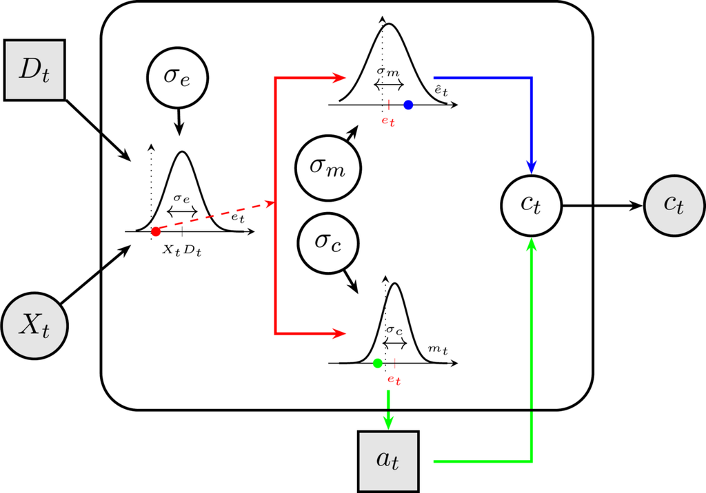

The model assumes that an agent is presented with a stimulus that has a direction $D_i$ (the true state of the world) and a strength $X_i$. An internal representation of the physical stimulus (evidence), $e_i$ (red point), is a noisy readout of the physical stimulus. This internal evidence is then sent to the pre-motor and motor cortex, where an efferent signal and an efference copy are produced (red split path). Due to additional noise ($\sigma_c$) in the processing and transmission of the signal to the limb, the action generated may be opposite to what the evidence indicated (green point). Simultaneously, the efference copy may also be subject to additional noise ($\sigma_m$). It is then used together with the action to produce a prediction error in the comparator $C_t$, which in turn generates the confidence rating.

Next, we present simulations from the model to build intuition about the parameters and their interact.

### Simulations

Below we demonstrate that the model reproduces key behavioral patterns of choice and confidence ratings under different parameter combinations. In brief, our simulations show that the ratio $\frac{\sigma_e}{\sigma_c}$ determines the degree of error monitoring and whether the confidence patterns is a folded-X or double-increase.

- A low ratio (high $\sigma_c$, low $\sigma_e$) produces folded-X (strong error monitoring), while a high ratio (low $\sigma_c$, high $\sigma_e$) produces double-increase (no error monitoring).
- The metacognitive noise $\sigma_m$ flattens the confidence curves regardless of accuracy.

Note: For all simulations below, we assume that the bias in evidence encoding $\beta$ is 0. We return to this issue later, in connection with the assumption about whether participants have access to the objective stimulus intensity.

First, we examine the distribution of internal evidence over the objective signed stimulus (i.e., the product of stimulus intensity and the true state) across the two parameters governing the choices; $\sigma_e$ (evidence encoding ) and $\sigma_c$ (choice variability).

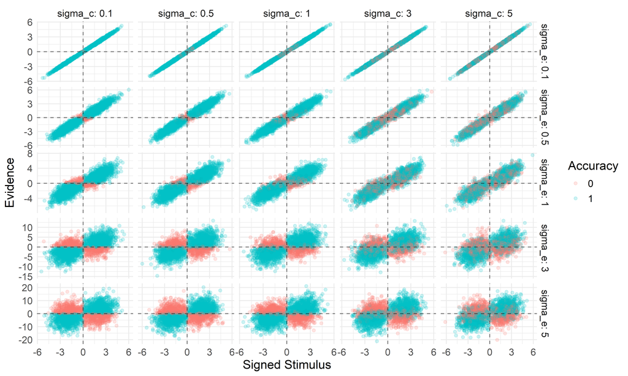

From the above plot we see that $\sigma_e$ broadens the range of observed evidence (making it noisier for the same external stimulus); moving down the rows, the y-axis range greatly increases. When $\sigma_c$ is low (left column), choices are consistent, positive evidence is paired with positive signed stimulus (i.e. D = 1), yielding a correct response. As $\sigma_c$ increases this relationship becomes noisier, and correct and incorrect choices become less distinguishable across the zero-evidence line and zero-signed-stimulus lines.

Another way to display this is by plotting actions instead of accuracy:

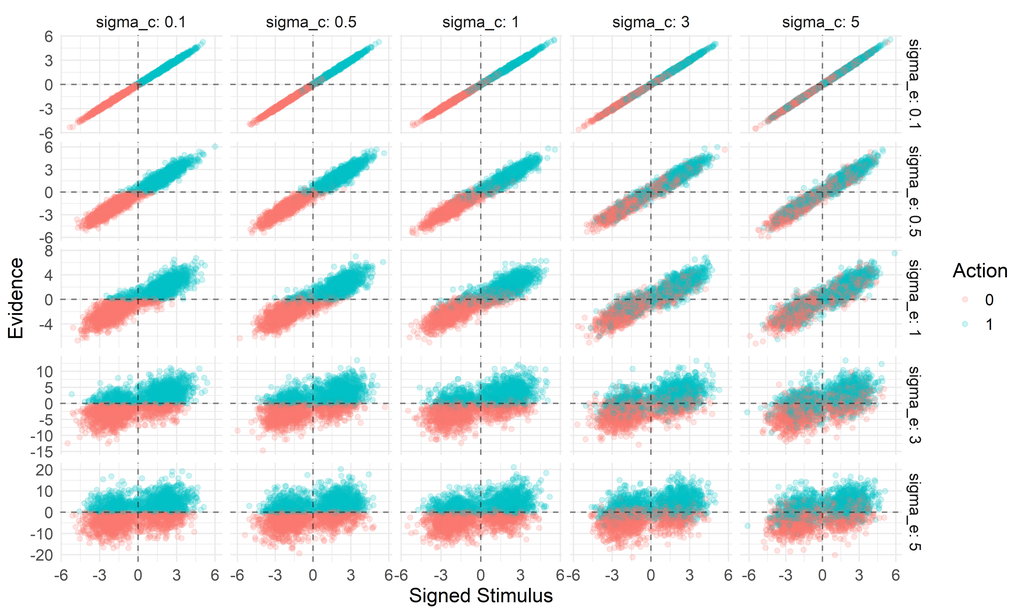

Next, we examine confidence ratings as a function of the three noise parameters.

First, we fix $\sigma_c = 1$ and examine how $\sigma_e$ & $\sigma_m$ change confidence ratings as a function of the signed stimulus intensity:

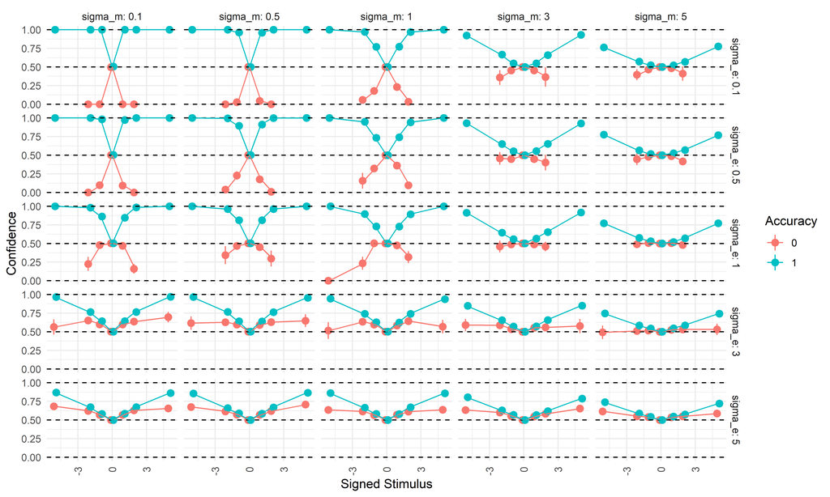

When confidence is plotted on the signed stimulus scale, a double-increase pattern emerges when $\sigma_e$ is high (moving down the facets), and a folded-X pattern appears when $\sigma_e$ is low (moving up the facets). As metacognitive noise ($\sigma_m$) increases (moving left to right), both confidence curves become increasingly flat (i.e., closer to 0.5) regardless of correctness.

Next, we fix $\sigma_e = 1$ and examine $\sigma_c$ and $\sigma_m$:

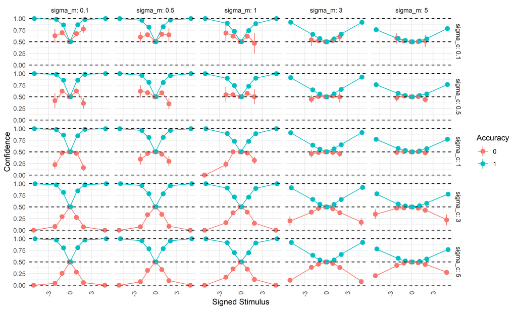

The pattern is similar to the previous plot. A high $\sigma_c$ produces a folded-X, whereas lower values (especially below 1) produce a double-increase. As before, increasing metacognitive noise ($\sigma_m$) flattens both confidence curves toward 0.5 regardless of correctness.

Lastly, we plot simulated data for varying $\sigma_c$ and $\sigma_e$ with $\sigma_m = 1$:

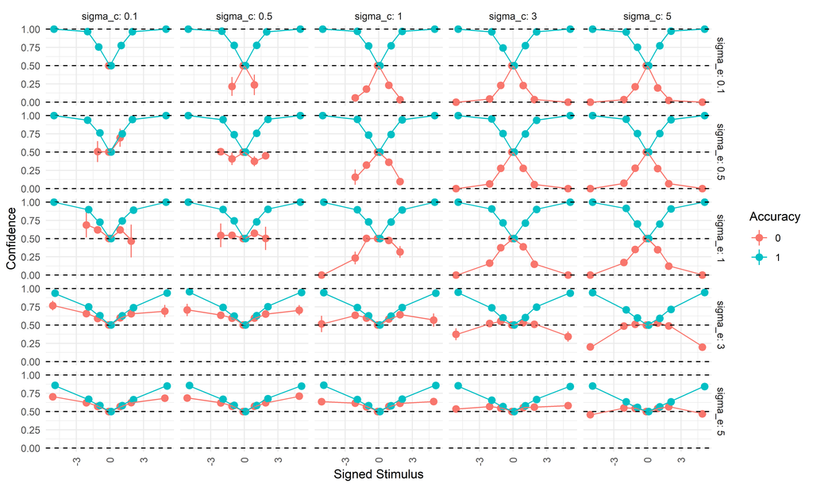

When $\sigma_e = \sigma_c$ (the diagonal), it becomes difficult to distinguish folded-X from double-increase patterns, because incorrect trials cluster around 0.5 and show little dependence on stimulus intensity. Correct trials increase in confidence with stimulus intensity across all parameter combinations. In the upper triangle (where $\sigma_c > \sigma_e$), folded-X patterns emerge, whereas in the lower triangle ($\sigma_c < \sigma_e$), double-increase patterns emerge.

These simulations show that, in the current model, the double-increase and folded-X patterns arise from different ratios of encoding noise to choice variability. When choice variability is high relative to encoding noise, a folded-X pattern arises; when choice variability is low relative to encoding noise, a double-increase pattern arises. Metacognitive noise ($\sigma_m$) is agnostic to the accuracy of the rater and, when it increases, flattens the confidence curves regardless of correctness.

### Fitting

We want to fit this model using full Bayesian inference with Stan’s NUTS sampler, treating the latent trial-by-trial evidence as parameters estimated jointly with subject-level noise parameters. In our pilot data, the model could be fit at the single-subject level with adequate sampler diagnostics. However, fitting it in a hierarchical framework (i.e., drawing subject-level parameters from group-level parameters) produced sampling issues. Because the current project uses a sequential sampling paradigm, a robust and efficient model is necessary. We therefore develop a heuristic model that approximates the model described above without requiring estimation of trial-by-trial evidence.

### The Heuristic model

The computational complexity of the above model, especially in hierarchical settings, motivates a simpler heuristic approximation. The key challenge is that confidence requires trial-specific evidence $r_i$, which cannot be marginalized analytically because the random variable is inside the inverse logit function.

The inverse logit function and the cumulative normal distribution are in practice nearly indistinguishable up to a scaling constant, i.e., $g(\cdot) \approx \Phi(\cdot / 1.7)$, as shown below:

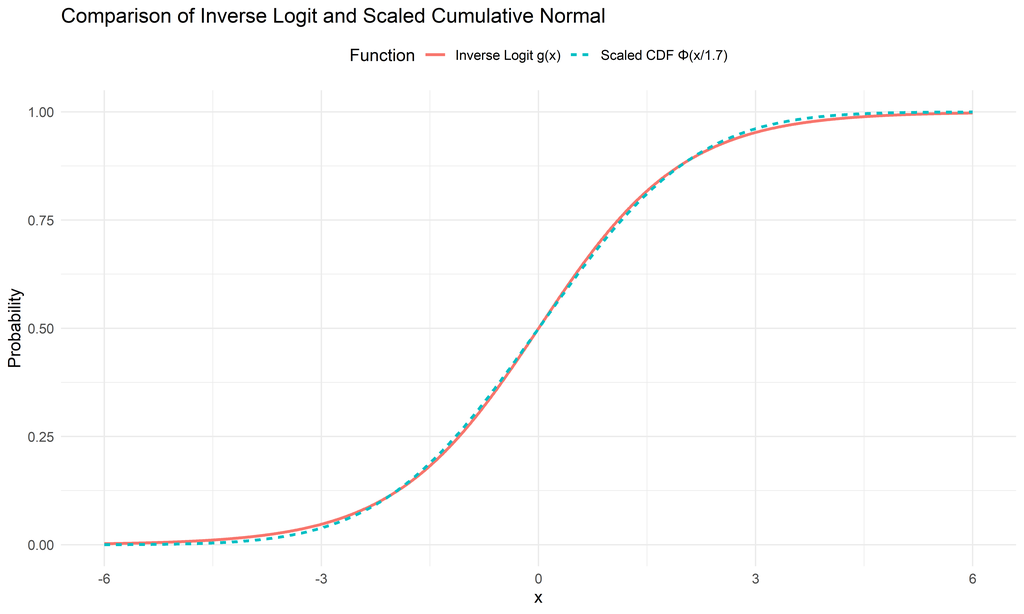

Using this approximation, it is possible to marginalize out the trial-by-trial evidence and arrive at a computationally less expensive model (and a closed-form equation for the expectation of confidence) that uses the same parameters.

With this approximation we go from equation (2) to the following:

$$P(\text{correct} \mid r_i, a, X_i) = \begin{cases}\Phi\left(\frac{C
\cdot r_i \cdot X_i}{\sigma_e^2 + \sigma_m^2}\right) & \text{if } a
= 1 \\ 1 - \Phi\left(\frac{C \cdot r_i \cdot X_i}{\sigma_e^2 +
\sigma_m^2}\right) & \text{if } a = -1\end{cases} \tag{3}$$

Where $C = \frac{2}{1.7}$.

Focusing on the case where the choice is $a = 1$:

$$\Phi\left(\frac{C \cdot r_i \cdot X_i}{\sigma_e^2 + \sigma_m^2}\right)$$

We want to marginalize over $r_i$, i.e. calculate the expectation of above equation, across $r_i$. This can be done using the general formula for the expectation of a random continuous variable.

$$\mathbb{E(X)} = \int_{-\infty}^\infty x \ p(x) dx$$

Substituting variables, with $b = \frac{CX_i}{\sigma_e^2 + \sigma_m^2}$

$$\int_{-\infty}^\infty \Phi(b \cdot r_i) \ p(r_i) dr_i$$

with $r_i \sim \mathcal{N}(\mu,\sigma)$

This integral can be shown to have the [solution](https://www.tandfonline.com/doi/abs/10.1080/03610918008812164):

$$\Phi \left(\frac{\mu \cdot b}{\sqrt{1+\sigma^2 \cdot b^2}}\right)$$

Given that $r_i \sim \mathcal{N}(X_iD_i - \beta, \sqrt{\sigma_m^2+\sigma_e^2})$, we get:

$$\Phi \left(\frac{\mathbb{E}(r_i) \cdot
b}{\sqrt{1+(\sigma_e^2+\sigma_m^2) \cdot b^2}}\right)$$

We write the expectation of $r_i$, rather than the distributional mean of $r_i$ i.e., $X_iD_i - \beta$, because this expectation will be conditional on the choice (recall we are considering $a_i = 1$).

Expanding and simplifying, we obtain:

$$\Phi\left(\frac{\mathbb{E}(r_i) \cdot CX_i}{ \sigma_e^2 + \sigma_m^2}
\cdot\frac{1} {\sqrt{1 + \frac{C^2X^2_i}{\sigma_e^2+\sigma_m^2}}}\right)$$

This equation gives the probability of being correct when the choice is 1. However, because the rater knows the actor’s choice and the rater’s evidence is a noisy readout of the evidence used to generate that choice, observing the choice provides additional information about the underlying evidence. Mathematically, if the rater uses all available information, the expectation of the evidence must be conditional on the actor’s choice.

Equation (3) therefore becomes:

$$P(\text{correct} \mid a, X_i) = \begin{cases}
\Phi\left(\frac{\mathbb{E}(r_i \mid a = 1) \cdot CX_i}{\sigma_e^2 +
\sigma_m^2} \cdot \frac{1}{\sqrt{1 +
\frac{C^2X^2_i}{\sigma_e^2+\sigma_m^2}}}\right) & \text{if } a = 1
\\
1 - \Phi\left(\frac{\mathbb{E}(r_i \mid a = -1) \cdot CX_i}{\sigma_e^2 +
\sigma_m^2} \cdot \frac{1}{\sqrt{1 +
\frac{C^2X^2_i}{\sigma_e^2+\sigma_m^2}}}\right) & \text{if } a = -1
\end{cases} \tag{4}$$

It can be shown that this conditional expectation equals the following equation (for a full derivation see below):

**📘 Click to expand: Calculating conditional expectations.**

The goal here is to derive the two expectations of $r_i$ given the choice i.e. $\mathbb{E}(r_i \mid a_i = 1)$ and $\mathbb{E}(r_i \mid a_i = -1)$

To derive these expectations, we need to account for the fact that the choice $a_i$ depends on the relationship between the evidence $e_i$ and the criterion $c_i$, and given that $r_i$ is a noisy readout of $e_i$ there is a dependency structure.

We have the following relationships:

- Evidence: $e_i \sim \mathcal{N}(X_iD_i - \beta, \sigma_e)$
- Criterion: $c_i \sim \mathcal{N}(0, \sigma_c)$
- Metacognitive evidence: $r_i = e_i + \epsilon_m$ where $\epsilon_m \sim \mathcal{N}(0, \sigma_m)$
- Choice: $a_i = 1$ if $e_i > c_i$, otherwise $a_i = -1$

we can treat the difference distribution $e_i - c_i$ as a joint bivariate normal distribution with $r_i$ and calculate the expectation of $r_i$ given that the $e_i - c_i$ random variable is above 0 (or equivalently that the choice was 1).

The difference $e_i - c_i$ follows a Gaussian distribution, as both random variables are Gaussian.

$$(e_i - c_i) \sim \mathcal{N}(X_iD_i - \beta, \sqrt{\sigma_e^2 +
\sigma_c^2})$$
The joint bivariate normal distribution becomes:

$$\begin{bmatrix}
e_i - c_i \\
r_i
\end{bmatrix}
\sim \mathcal{N}\left(
\begin{bmatrix}
X_iD_i - \beta \\
X_iD_i - \beta
\end{bmatrix},
\begin{bmatrix}
\sigma_e^2 + \sigma_c^2 & \sigma_e^2 \\
\sigma_e^2 & \sigma_e^2 + \sigma_m^2
\end{bmatrix}
\right)$$

Intuitively this bivariate normal distribution can be argued for by realizing that both distributions of $e_i - c_i$ and $r_i$ share $e_i$, with the same mean but are otherwise independent.

The key mathematical insight is that the covariance between $e_i-c_i$ and $r_i$ is $\sigma_e^2$ and not zero.

Writing the full covariance and expanding it using this we get:

$$\text{Cov}(e_i-c_i, r_i) = \text{Cov}(e_i-c_i, e_i + \epsilon_m)$$
$$\text{Cov}(e_i-c_i, r_i) = \text{Cov}(e_i,e_i) + \text{Cov}(e_i,
\epsilon_m) - \text{Cov}(c_i,e_i) - \text{Cov}(c_i,
\epsilon_m)= \text{Cov}(e_i,e_i) = \text{Var}(e) =\sigma_e^2$$
As $e_i$ and $\epsilon_m$ and also $c_i$ are independent, these covariances are 0:

$$\text{Cov}(e_i-c_i, r_i) = \text{Cov}(e_i,e_i) = \text{Var}(e)
=\sigma_e^2$$

This shared variance structure means that $e_i-c_i$ and $r_i$ are correlated with correlation coefficient.

$$\rho = \frac{\sigma_e^2}{\sqrt{(\sigma_e^2 + \sigma_c^2)} \cdot
\sqrt{(\sigma_e^2 + \sigma_m^2)}} \tag{5}$$

#### Truncated normal distributions

To proceed, we need a general result from probability theory. Suppose we have two jointly normal random variables:

$$\begin{pmatrix} Z \\ Y \end{pmatrix} \sim
\mathcal{N}\left(\begin{pmatrix} \mu_Z \\ \mu_Y \end{pmatrix},
\begin{pmatrix} \sigma_Z^2 & \rho\sigma_Y\sigma_Z \\
\rho\sigma_Y\sigma_Z & \sigma_Y^2 \end{pmatrix}\right)$$
It can be shown that the expectation of Y given Z>0 is:

$$\mathbb{E}(Y \mid Z > 0) = \mu_Y + \rho\cdot
\sigma_Y\frac{\phi(z_z)}{\Phi(z_z)}$$

With $z_Z = \frac{\mu_Z}{\sigma_Z}$

For a full derivation see; Derivation.

Now replacing Y with $r_i$ and Z with $e_i - c_i$ we get:

$$\mathbb{E}(r_i \mid (e_i-c_i) > 0) = (X_iD_i - \beta) + \rho \cdot
\sqrt{\sigma_e^2 + \sigma_m^2} \cdot \frac{\phi(z_z)}{\Phi(z_z)}$$

With $z_z = \frac{X_iD_i - \beta}{\sqrt{\sigma_e^2 + \sigma_c^2}}$

It can then easily be shown using the same steps that when the action is -1 i.e. $(e_i-c_i) < 0$ this becomes:

$$\mathbb{E}(r_i \mid (e_i-c_i) < 0) = (X_iD_i - \beta) - \rho \cdot
\sqrt{\sigma_e^2 + \sigma_m^2} \cdot \frac{\phi(-z_z)}{\Phi(-z_z)}$$

we might define $\lambda(x) = \frac{\phi(x)}{\Phi(x)}$, which is the inverse Mills ratio.

$$\mathbb{E}(r_i \mid a = 1) = (X_iD_i - \beta) + \rho \cdot
\sqrt{\sigma_e^2 + \sigma_m^2} \cdot \lambda\left(\frac{X_iD_i -
\beta}{\sqrt{\sigma_e^2 + \sigma_c^2}}\right)$$

For $a = -1$:

$$\mathbb{E}(r_i \mid a = -1) = (X_iD_i - \beta) - \rho \cdot
\sqrt{\sigma_e^2 + \sigma_m^2} \cdot \lambda\left(-\frac{X_iD_i -
\beta}{\sqrt{\sigma_e^2 + \sigma_c^2}}\right)$$

Here $\lambda(x) = \frac{\phi(x)}{\Phi(x)}$, and $\rho = \frac{\sigma_e^2}{\sqrt{(\sigma_e^2 + \sigma_c^2)} \cdot \sqrt{(\sigma_e^2 + \sigma_m^2)}}$.

### Final confidence model

Substituting these conditional expectations back into equation (4) and simplifying gives:

$$P(correct \mid a = 1, X_i, D_i) = \Phi\left(\left[\frac{(CX_i^2D_i -
C\beta X_i)}{\sigma_e^2 + \sigma_m^2} + \rho \cdot \frac{
\lambda\left(\frac{X_iD_i - \beta}{\sqrt{\sigma_e^2 +
\sigma_c^2}}\right)CX_i}{\sqrt{\sigma_e^2 + \sigma_m^2} }\right]
\cdot\frac{1} {\sqrt{1 + \frac{C^2X^2_i}{\sigma_e^2+\sigma_m^2}}}\right)$$

This gives a fully marginalized model for confidence ratings (for choices of $a = 1$) that depends only on the parameters $\Theta_1 = (\beta, \sigma_e, \sigma_c, \sigma_m)$ and the observed data (choices $a_i$, stimuli $X_i$, and true states $D_i$), without requiring trial-by-trial estimation of the latent evidence variables $e_i$ and $r_i$.

Before interpreting this equation, we return to a key assumption outlined just after equation (2): computing the subjective probability of being correct requires that the participant has access to the stimulus intensity. Below, we highlight the two $X_i$ terms in the equation that depend on this assumption:

$$P(\text{correct} \mid a = 1, X_i, D_i) = \Phi\left(\frac{\left[(X_iD_i -
\beta) + \rho \cdot \sqrt{\sigma_e^2 + \sigma_m^2} \cdot
\lambda\left(\frac{X_iD_i - \beta}{\sqrt{\sigma_e^2 +
\sigma_c^2}}\right)\right] \cdot C \mathbf{X_i}}{ \sigma_e^2 +
\sigma_m^2} \cdot\frac{1} {\sqrt{1 +
\frac{C^2\mathbf{X^2_i}}{\sigma_e^2+\sigma_m^2}}}\right)$$

These two stimulus intensity terms (shown in bold), especially the first (which does not arise from the marginalization), ensure that at intensity 0 the predicted confidence is always 0.5. This is a strong assumption: it requires the agent to have access to the objective stimulus strength, and the assumption is also inconsistent with the empirical observation (highlighted in Part 1) that the lowest confidence rating shifts with bias. If confidence ratings are treated as noisy, biased subjective probabilities of being correct, the formulation above becomes problematic because of its reliance on an objective anchor at $X_i = 0$. Based on these considerations, supported by empirical validation on our pilot data below, we believe this particular stimulus intensity term, which rests on an unjustified assumption, needs to be addressed.

One possible solution is to assume that the agent has a noisy readout of stimulus strength, $\hat{X} \sim p(\hat{x}|\theta,c)$. The difficulty with this formulation is defining the probability distribution of the internal stimulus intensity. This distribution must be positively bounded ($\hat{X} > 0$), which introduces an arbitrary distributional choice and, more importantly, makes it nontrivial to marginalize the trial-by-trial readout. An alternative approach would be to replace the stimulus intensity with a participant-specific constant, serving as a placeholder for idiosyncratic differences in how participants use stimulus intensity information beyond what they should have access to.

Instead, we assume that agents do not have access to this stimulus intensity and fix it to 1. This approach circumvents the computational difficulties mentioned above while remaining consistent with what the agent is assumed to have access to. It also allows the model to accommodate the empirical observation that the confidence curve follows the psychometric function of the binary choices. Below, we show that in our pilot data, the two models (fixing this stimulus intensity to 1 versus letting it vary with the true stimulus intensity) have equivalent approximate leave-one-out cross-validation performance.

The final equations becomes:

$$P(\text{correct} \mid a = 1, X_i, D_i) = \Phi\left(\left[\frac{(CX_iD_i
- C\beta)}{\sigma_e^2 + \sigma_m^2} + \rho \cdot \frac{
\lambda\left(\frac{X_iD_i - \beta}{\sqrt{\sigma_e^2 +
\sigma_c^2}}\right)C}{\sqrt{\sigma_e^2 + \sigma_m^2} }\right]
\cdot\frac{1} {\sqrt{1 + \frac{C^2}{\sigma_e^2+\sigma_m^2}}}\right)
\tag{7a}$$

which for $a = -1$ becomes:

$$P(\text{correct} \mid a = -1, X_i, D_i) =
1-\Phi\left(\left[\frac{(CX_iD_i - C\beta)}{\sigma_e^2 + \sigma_m^2} -
\rho \cdot \frac{ \lambda\left(-\frac{X_iD_i - \beta}{\sqrt{\sigma_e^2 +
\sigma_c^2}}\right)C}{\sqrt{\sigma_e^2 + \sigma_m^2} }\right]
\cdot\frac{1} {\sqrt{1 + \frac{C^2}{\sigma_e^2+\sigma_m^2}}}\right)
\tag{7b}$$

with:

$$\begin{aligned}
\lambda(x) &= \frac{\phi(x)}{\Phi(x)} \\
C &= \frac{2}{1.7}
\end{aligned}$$

In the above formula it is noteworthy that the terms inside the cumulative normal distribution function have clear interpretations.

First, the common factor is a correction for marginalization:

$$K_i = \frac{1}{\sqrt{1 + \frac{C^2}{\sigma_e^2+\sigma_m^2}}}$$

The two remaining terms have direct cognitive interpretations. Returning to equation (3) (now with $X_i = 1$), the first term from equations (7a/7b) is the expectation of the log-likelihood ratio (the argument inside $\Phi(\cdot)$). It can be interpreted as the **prior belief about being correct based purely on the stimulus**, before any information about the action is taken into account:

$$I_i = \mathbb{E}\left(\frac{C \cdot r_i}{\sigma_e^2 + \sigma_m^2}\right)
= \frac{C(X_iD_i - \beta)}{\sigma_e^2 + \sigma_m^2}$$

The second term updates this prior using the information carried by the action via the efference copy:

$$S_i = \pm\rho \cdot \frac{\lambda\left(\pm\frac{X_iD_i -
\beta}{\sqrt{\sigma_e^2 + \sigma_c^2}}\right)C}{\sqrt{\sigma_e^2 +
\sigma_m^2}}$$

This term functions as an **internal action prediction error**: it reflects the discrepancy between the action the evidence predicted and the action actually executed, as observed through the noisy efference copy channel. Its magnitude is governed by the inverse Mills ratio $\lambda(\cdot)$, which is large when the action was surprising given the evidence (i.e., errors at high stimulus intensity) and near zero when the action was expected (i.e., correct responses at high stimulus intensity). Confidence in probit space is therefore the sum of a prior and a prediction error, scaled by the correction factor:

$$\Phi^{-1}(\mu_{c_i}) = (I_i + S_i) \cdot K_i$$

This is analogous to a reinforcement learning rule where a prior value estimate is corrected by a prediction error, but here no external feedback is necessary; the efference copy itself serves as the internal reference signal. The addition of action information to the confidence computation was proposed in the second-order rater model of Stephen M. Fleming and Daw (2017), with empirical support from reanalysis of behavioral data. The present formulation makes the mechanism explicit: the efference copy supplies the prediction error.

For completeness, we show the magnitude of these two terms as a function of signed stimulus intensity. For a range of stimulus intensities $U(0.05,1)$, we show how both $I_i$ and $S_i$ vary with choice correctness.

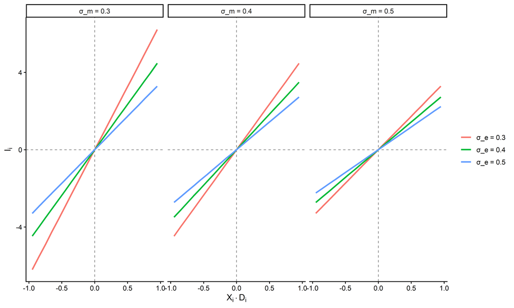

Here $\sigma_m$ and $\sigma_e$ have qualitatively the same effect on $I_i$, both reduce the strength of the relationship between signed stimulus intensity and average evidence in favor of the true state.

Next, we examine how the parameters influence the second term $S_i$. First, we plot varying levels of $\sigma_m$ with $\sigma_e = 0.5$ and $\sigma_c = 0.5$

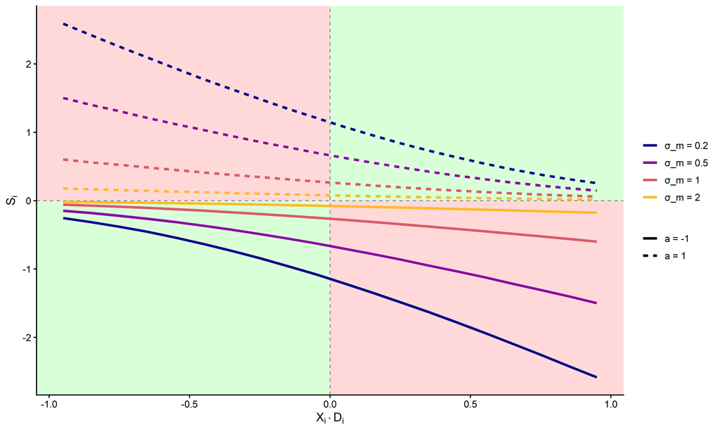

In the above plot, each quadrant corresponds to a different state of the decision process. Green quadrants indicate correct responses; red quadrants indicate errors. Line color represents different levels of metacognitive noise $\sigma_m$. The magnitude of $S_i$ is uniformly attenuated as $\sigma_m$ increases.

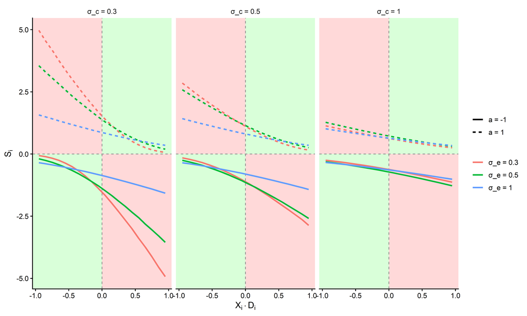

To summarize, confidence in this model is the sum of a stimulus-based prior $I_i$ and an action-based prediction error $S_i$, scaled by the marginalization factor $K_i$. The prediction error is largest for incorrect responses at high stimulus intensity and smallest for correct responses at high stimulus intensity. This pattern has implications for how physiological responses, particularly pupil dilation, may track the decision process.

#### Additional parameters

We introduce 5 additional parameters. $\Theta_2 = (\kappa_c, \gamma, \mu_{\beta}, c_0,c_1)$.

- $\gamma$ is the lapse rate on the binary choices, a stimulus independent factor that shifts the asymptote of the psychometric function away from certainty i.e., the asymptotes become $\gamma$ and $1-\gamma$.
- $\mu_{\beta}$ is a metacognitive bias parameter, serving as an independent vertical shift of confidence ratings.
- $\kappa_c$ is the precision of the ordered beta likelihood.
- $c_0$,$c_1$ are the two cutpoints for the ordered beta likelihood. These two parameters help generalize the beta-distribution to outcomes that include 0 and 1 ratings.

See (Kubinec 2023) for the ordered beta likelihood.

The complete set of parameters for the model is:

$$\begin{aligned}
\Theta_s &= \begin{bmatrix}
\beta_s \\
\sigma_{e_s} \\
\sigma_{c_s} \\
\sigma_{m_s} \\
\mu_{\beta_s} \\
\kappa_{c_s} \\
\gamma_s
\end{bmatrix}
\sim
\mathcal{N}(\mu_{\Theta},\Sigma_{\Theta}) \\
\text{where } & \beta_s \in [-1,1], \sigma_{e_s} >0,
\sigma_{c_s} >0, \sigma_{m_s} > 0, \\
& \mu_{\beta_s} \in \mathbb{R}, \kappa_{c_s} > 0, \gamma_s \in
[0,0.5] \\
& (c_{1_s} , c_{0_s}) \sim \delta([1,10,1])
\end{aligned}$$

In this formulation, $\mathcal{N}$ denotes a multivariate normal distribution with mean and covariance. All parameter constraints are enforced through transformations: positively constrained parameters are exponentiated, and bounded parameters are transformed with the inverse logit function and scaled appropriately. The cutpoint constraints are imposed via a Dirichlet prior ($\delta()$). Note that cutpoints are sampled on a subject-by-subject basis.

The priors of the model are as follows:

$$\begin{align*}
\mu_{\beta} &\sim \mathcal{N}(0, 0.5) & \text{(group mean of
threshold)} \\
\mu_{\sigma_{e_s}} &\sim \mathcal{N}(-2, 2) & \text{(group mean
of encoding uncertainty)} \\
\mu_{\sigma_{c_s}} &\sim \mathcal{N}(-2, 2) & \text{(group mean
of choice variability)} \\
\mu_{\sigma_{m_s}} &\sim \mathcal{N}(-2, 2) & \text{(group mean
of meta uncertainty)} \\
\mu_{\beta_c} &\sim \mathcal{N}(0, 0.5) & \text{(group mean of
meta bias)} \\
\mu_{\gamma_s} &\sim \mathcal{N}(2, 2) & \text{(group mean of
lapse rate)} \\
\mu_{\kappa_c} &\sim \mathcal{N}(-4, 2) & \text{(group mean of
confidence precision)} \\
\end{align*}$$

$$\begin{align*}
\tau_{\beta} &\sim \mathcal{N}(1, 1) & \text{(Between subject SD
of threshold)} \\
\tau_{\sigma_{e_s}} &\sim \mathcal{N}(1, 1) & \text{(Between
subject SD of encoding uncertainty)} \\
\tau_{\sigma_{c_s}} &\sim \mathcal{N}(1, 1) & \text{(Between
subject SD of choice variability)} \\
\tau_{\sigma_{m_s}} &\sim \mathcal{N}(1, 1) & \text{(Between
subject SD of meta uncertainty)} \\
\tau_{\beta_c} &\sim \mathcal{N}(1, 1) & \text{(Between subject
SD of meta bias)} \\
\tau_{\gamma_s} &\sim \mathcal{N}(1, 1) & \text{(Between subject
SD of lapse rate)} \\
\tau_{\kappa_c} &\sim \mathcal{N}(1, 1) & \text{(Between subject
SD of confidence precision)} \\
\end{align*}$$

- $\mathbf{R} \sim \mathrm{LKJ}(\eta = 2)$ (correlation matrix for the multivariate normal distribution.)
- $z_{expo} \sim \mathcal{N}(0, 1)$ (participant deviations)
- $c_0, c_{1}$: see Dirichlet prior in Stan code

The full model is

$$\begin{aligned}
P(a = 1) &= \Phi\left(\frac{D_i \cdot X_i-
\beta_s}{\sqrt{\sigma_{e_s}^2 + \sigma_{c_s}^2}}\right) \\
\mu_{c_i} &= \begin{cases}\Phi\left((I_i-S_i)\cdot K_i\right) &
\text{if } a_i = 1 \\
1 - \Phi\left((I_i+S_i)\cdot K_i\right) & \text{if } a_i =
-1\end{cases} \\
a_i &\sim \mathcal{bernoulli}(p(a_i = 1)) \\
Conf_i &\sim
\mathcal{ord\beta}(\mu_{c_i},\kappa_{c_s},c_{0_s},c_{1_s})
\end{aligned}$$

with

$$I_i = \frac{(CX_iD_i - C\beta)}{\sigma_{e_s}^2 + \sigma_{m_s}^2}, \quad
S_i = -\rho_s \cdot \frac{ \lambda\left(-\frac{X_iD_i -
\beta_s}{\sqrt{\sigma_{e_s}^2 +
\sigma_{c_s}^2}}\right)C}{\sqrt{\sigma_{e_s}^2 + \sigma_{m_s}^2} },
\quad
K_i = \frac{1} {\sqrt{1 + \frac{C^2}{\sigma_{e_s}^2+\sigma_{m_s}^2}}}$$

Next, we verify the marginalized heuristic model by simulating data from equation (2) (with $X_i = 1$), averaging across the signed stimulus axis, and displaying the predictions of the marginalized heuristic model for the same parameter values ($\Theta_1$).

In the first validation step, we simulate from different combinations of noise parameters (shown as facets).

[figure not shown]

The above plot shows results from averaging 5^{5} simulated trials from equation (2) for each bin of the signed stimulus intensity scale (dots are means with approximate 95% intervals). The thick solid lines represent the marginalized heuristic model predictions.

Next, we simulate using fixed noise parameters and vary the bias $\beta$. Note that here we display the action rather than the accuracy of the choice.

[figure not shown]

The above plot shows results from averaging 5^{5} simulated trials from equation (2) for each bin of the signed stimulus intensity scale (dots are means with approximate 95% intervals). The thick solid lines represent the marginalized heuristic model predictions.

### Model for the current experiment.

In the current experiment, participants are presented with a random dot kinematogram on each trial and asked to choose which direction the majority of dots are moving. After an experimental delay (post-decisional response window), participants give a confidence rating. We aim to test whether this post-decisional response window changes the metacognitive noise and metacognitive bias parameters of the above model. This is implemented as follows:

$$\sigma_{m_t} = \sigma_{m_s} + \Delta{\sigma_{m_s}} \cdot PDW_t\\
\mu_{\beta_t} = \mu_{\beta_s} + \Delta{\mu_{\beta_s}} \cdot PDW_t$$

The subject-level changes due to the post-decisional window (PDW) are drawn from additional group-level parameters in the multivariate normal distribution described above. These group-level parameters are given the following priors:

$$
$$\begin{align*}
\mu_{\Delta{\sigma_{m_s}}} &\sim \mathcal{N}(0, 0.5) &
\text{(group mean of effect of PDW on meta uncertainty)} \\
\mu_{\Delta{\mu_{\beta_c}}} &\sim \mathcal{N}(0, 0.5) &
\text{(group mean of effect of PDW on meta bias)} \\
\tau_{\Delta{\sigma_{m_s}}} &\sim \mathcal{N}(0, 0.5) &
\text{(Between subject SD of effect of PDW on meta uncertainty)} \\
\tau_{\Delta{\mu_{\beta_c}}} &\sim \mathcal{N}(0, 0.5) &
\text{(Between subject SD of effect of PDW on meta bias)} \\
\end{align*}$$
$$

- PDW denotes the post-decisional response window.
- ${\Delta{\sigma_{m_s}}}$ and $\Delta{\mu_{\beta_c}}$ denote the change in metacognitive noise and metacognitive bias due to PDW, respectively.

### Model comparison

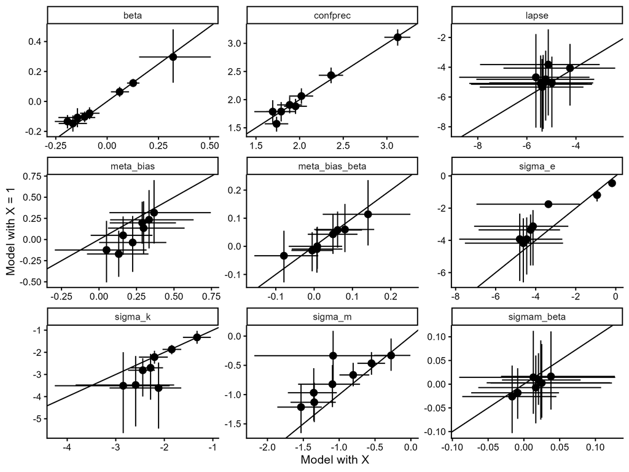

### Posterior predictive checks

Next, we show posterior predictive checks of the hierarchical heuristic model for our pilot participants.

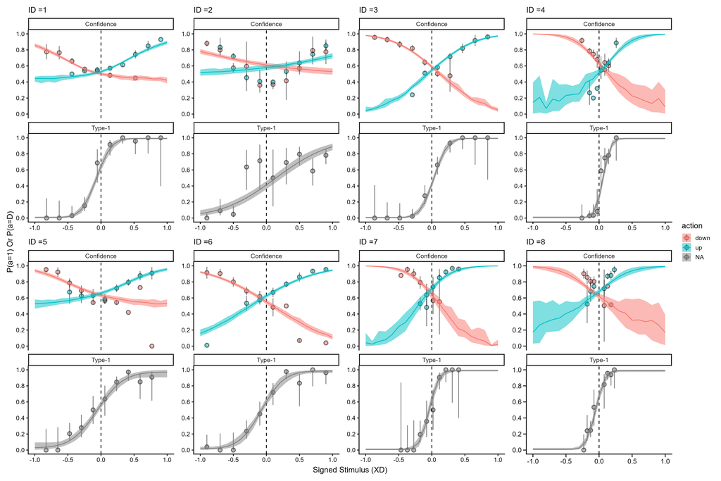

### Hierarchical parameter recovery

To further assess the robustness of our model implementation and the planned sequential sampling procedure, we simulated new participants from the posterior distribution of the hierarchical model. We extracted a single posterior draw and simulated 25 participants from it, then fitted the model to increasing numbers of participants (5, 7, 9, 12, 15, 20, 25) to demonstrate that the sequential sampling approach is feasible. This also allowed us to perform parameter recovery on the hierarchical model without additional computational resources. Below, we show that the model adequately recovers its parameters at both the subject and group level for parameters of interest.

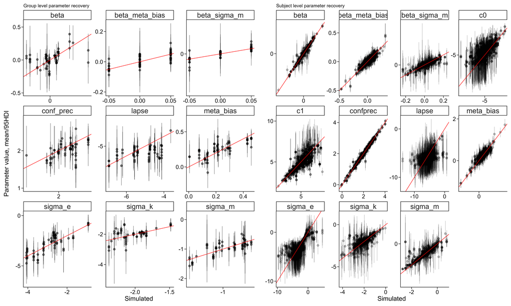

### Sequential sampling

#### Priors

Because our sequential sampling approach uses Bayes factors for the termination of data collection, the prior distributions are highly influential. For transparency, we visualize the curves permitted by the prior below. Interested readers are also referred to the Sequential Sampling directory, which contains scripts for fitting, visualizing, and diagnosing our model.

[figure not shown]

The plot above shows prior predictive checks of the group-level parameters (i.e., these curves represent group-level predictions). The curves span a wide range of possible patterns. To test whether our sequential sampling approach works, we simulate data from draws of the posterior distribution of our pilot data and examine how the Bayes factors for both hypotheses evolve as more participants are collected. Rather than using posterior draws of the parameters of interest ($\mu_{\Delta{\sigma_{m_s}}}$ and $\mu_{\Delta{\mu_{\beta_c}}}$), we fixed these to $-0.05$, $0$, or $0.05$ to test whether we can detect effects of this magnitude in both directions and also terminate sampling when the effect is zero. Below, we display the size of these effects (simulated from the mean of the group means).

[figure not shown]

As described above, we simulated participants from draws of the posterior informed by our pilot data. We then fitted the model to increasing numbers of participants (5, 7, 9, 12, 15, 20, 25) to demonstrate the feasibility of the sequential sampling approach. Below, we show five such trajectories of Bayes factors as a function of sample size, alongside a panel showing how the posterior distribution of the parameter of interest changes with increasing sample size.

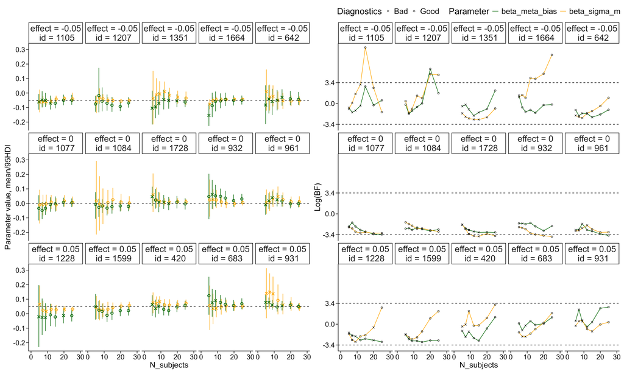

The above plot shows how the estimated effect of the interval between choice and confidence rating evolves for both metacognitive bias (green) and metacognitive noise (orange). Circles indicate fitted models without divergences, with effective sample sizes above 400 for both bulk and tails and $\hat{R}$ values below 1.03. The left panel displays the posterior distribution of each parameter for increasing sample sizes. The right panel displays the corresponding Bayes factors for the same posterior draws fitted to our pilot data.

The above plot also shows that convergence issues may arise even with this model. Below, we describe our approach for identifying and handling convergence issues.

We will collect data from 15 participants before fitting the hierarchical model for the first time and testing the Bayes factor, because hierarchical models generally require a minimum amount of data to converge (see also the simulation above). After this initial fit, we will check the Bayes factor after each additional 5 participants, which coincides with the expected number of participants collected per day.

# Part 3: Design, Methods, and Hypotheses

## Experimental study

This study examines motion discrimination and metacognition in a Random Dot Motion (RDM) task. Specifically, we ask whether the time between a first-order choice and a confidence judgements (post-decisional time) influences metacognitive uncertainty. We operationalize this as whether confidence ratings track the probability of being correct more closely when participants are required to wait longer before giving their confidence ratings, than when they can respond immediately

Dynamic models of metacognition assume that evidence is accumulated until a response boundary is reached and a binary decision is initiated. After the binary choice, additional evidence is assumed to be accumulated post-decisionally to inform the confidence rating. If this post-decisional evidence accumulation is informative about the correctness of the choice, increasing the post-decisional time window should improve the quality of the confidence ratings. This improvement would be shown as confidence ratings more closely approximating the objective probability that the choice was correct. However, if the evidence used for the confidence rating is already fully computed around the time of the decision (i.e., pre-decisionally), one would expect no difference, or even the opposite effect. Confidence ratings becoming less consistent with the probability of being correct would indicate that some information leakage is taking place, perhaps due to memory constraints. In this study, we manipulate the post-decisional time window to examine its effects on the quality of confidence ratings. Previous studies of post-decisional evidence accumulation have generally found that such accumulation is easiest to detect in speeded decision-making tasks, particularly on easy trials, where increased post-decisional time can decrease confidence ratings for incorrect choices.

In this study, we use a non-speeded perceptual decision-making task with individually calibrated difficulty levels ranging from very easy to very hard. We test whether post-decisional evidence accumulation can unfold over a longer time period even in non-speeded tasks. Because previous literature on this question is inconclusive, we adopt a Bayesian sequential-sampling framework. This approach allows us to quantify evidence for the null hypothesis (that post-decisional time does not change the quality of confidence ratings) and to collect only the number of participants necessary to reach a decision threshold.

### Computational model

To test whether the post-decisional response window changes how informative confidence ratings are about choice correctness, we constructed a hierarchical Bayesian model grounded in signal detection theory and motor control theory. The model assumes that agents exhibit variability both in the encoding of the physical stimulus, as in traditional signal detection theory, and in the selection of a choice given the internal evidence. Consistent with motor control theories, the model assumes that an efference copy is generated before the efferent signal is sent to the acting limb. This efference copy is corrupted by additional noise, consistent with other generative metacognition models, before being combined with the executed action to compute confidence in the chosen response. The model accounts for error monitoring through the inclusion of choice variability. For the full derivation and simulations, see the accompanying model markdown. Here it suffices to note that the metacognitive uncertainty parameter $\sigma_m$ governs the relationship between confidence ratings and choice correctness, as $\sigma_m$ increases, confidence becomes less informative about whether the choice was correct.

### Hypotheses

1. **Hypothesis 1:** Increasing the post-decisional time window will lead to no improvement in the relationship between confidence and accuracy.
   - **Test specification:**  
     This hypothesis is tested by allowing the metacognitive uncertainty ($\sigma_m$) parameter to vary linearly on the log scale with the post-decisional time window. Because this is the main parameter of interest, we will sequentially test whether the Bayes factor for this parameter has reached our termination criteria of either 30 or 1/30.
2. **Hypothesis 2:** Increasing the post-decisional time window will lead to no difference in confidence bias.
   - **Test specification:**  
     This hypothesis is tested by allowing the $mu_{\beta_c}$ parameter to vary by post-decisional time window. The primary test evaluates whether the group-level parameter differs from 0 (i.e., whether the 95% highest density interval includes 0). We also aim to report the Bayes factor to quantify the strength of the evidence relative to the null (i.e., there is no difference). This test will be conducted when the data collection has been terminated.

### Priors and Sequential Sampling.

To limit the number of participants needed to obtain sufficient evidence, we will use a sequential-sampling design. Recruitment will be terminated when the Bayes factor described above reaches either 30 or 1/30, or when 50 non-excluded participants have been collected. We will begin examining the Bayes factor in increments of 5 participants once 15 non-excluded participants have been reached (see exclusion criteria). This minimum of 15 is set to ensure stability of the model estimates; the increment of 5 reflects our expected daily testing rate. The Bayes factor used in this study is the Savage-Dickey density ratio evaluated at 0 (Wagenmakers et al. 2010).

Below we define the initial sampler parameters, the convergence diagnostics we require, and contingency plans if the sampler does not converge.

#### Initial Sampler Configuration

The model is initially estimated using the following sampler settings:

- Number of chains: 4
- Number of iterations per chain: 1000
- Warmup iterations: 1000
- Target acceptance rate (`adapt_delta`): 0.95
- Maximum tree depth (`max_treedepth`): 12

These values represent our baseline configuration for model estimation.

##### Convergence Criteria

Sampler convergence and reliability will be assessed using the following diagnostics:

- $\hat{R}$ values below 1.03 for all group level parameters
- Effective sample size (ESS) above 400 for all group level parameters
- Zero divergent transitions after warmup
- No saturation of the maximum tree depth
- Well-mixing trace plots

If these criteria are met, the sampling procedure will be considered satisfactory.

##### Contingency Procedures

If the above convergence criteria are not met, we will apply the following steps depending on the convergence failure:

- Increase the number of iterations.
- Increase the target acceptance rate (`adapt_delta`).
- Increase the maximum tree depth (`max_treedepth`).
- Reconsider model parameterization (i.e. centered vs non-centered parameterization).
- Estimate the lapse-rate parameter non-hierarchically
- Estimate the choice variability parameter non-hierarchically

These steps are intended to improve sampler stability and ensure reliable posterior estimation.

The full Stan model and the scripts for checking diagnostics and model fit are available in the sequential-sampling directory (`../Sequential Sampling`).

## Participants

Eligible participants will be 18–40 years old, have normal or corrected-to-normal vision, and be proficient in English. Individuals with neurological or psychiatric diagnoses, or those taking medication that may affect cognitive performance, will not be eligible. Participants will be recruited through COBE Lab’s participant pool to ensure fast and effective recruitment and will be compensated 110 DKK.

## Design

In total, participants will complete 288 trials, spread over 8 blocks of 36 trials. Pilot data indicated that this trial count was sufficient for good subject-level-parameter estimation. Before the main experiment begins, participants receive instructions on how to perform the decision task. They then complete six easy, non‑speeded practice trials without confidence ratings, followed by 120 more difficult practice trials. Afterward, participants receive additional instructions about the confidence scale and complete 10 easy, non‑speeded practice trials that include confidence ratings, after which the main experiment begins. The key variables of interest are response choice, accuracy, response time, confidence rating, and the response time associated with those confidence rating.

To ensure that task difficulty is calibrated at the individual level, the 120 harder practice trials serve as a staircase procedure. In a random dot kinematogram, task difficulty is determined by several stimulus properties, that can be broadly grouped into two categories: stimulus parameters and stimulus noisiness. To ensure that difficulty is optimally calibrated for each participant, we use the first 40 of the harder practice trials to staircase the dotlife parameter in the Dotstimclass in [psychopy](https://www.psychopy.org/api/visual/dotstim.html). This parameter determines how many frames a dot persists before disappearing. Once an appropriate dot‑life value is identified, we begin staircasing coherence. Coherence controls the stimulus signal-to-noise ratio and is the most commonly manipulated difficulty parameter in the literature. It ranges from 0 to 1 and determines the proportion of signal to noise dots, with higher values indicating a greater proportion of signal dots.

The remaining 80 trials are used to estimate the slope and threshold of the participant’s psychometric function on coherence. Both staircases are implemented in PsychoPy using the QUEST+ Bayesian adaptive procedure, which selects each stimulus to minimize posterior entropy over the psychometric parameters (Watson 2017). Using the estimated psychometric function, we determine the coherence levels for the main experiment based on a set of predefined target accuracies ($ACC = [0.51, 0.6, 0.7, 0.8, 0.99]$). The corresponding coherence values are then sampled in a quasi‑normal fashion: the extreme accuracy levels (0.51 and 0.99) appear once per direction, the intermediate levels appear twice, and the 0.70 level appears three times. In each block of the main experiment, trials are presented in a pseudo‑randomized sequence of upward and downward motion such that no more than three consecutive trials share the same direction. This reduces the risk of implicit directional bias. Together, these procedures ensure that participants use the full confidence scale and that difficulty is balanced across upward and downward motion directions.

## Exclusion criteria

Because the task is a two‑alternative forced‑choice decision, chance performance is 50%. For each participant, we will compute overall accuracy across all main‑task trials and will exclude all participants with an accuracy lower than 60%. For our trial count, accuracy below this threshold is not reliably above chance under a binomial model of guessing. Furthermore, given the stimulus calibration procedure, an optimal observer is expected to achieve approximately 71% accuracy. Accuracy below 60% is therefore inconsistent with meaningful task engagement.

Additionally, trials with a response time below 150 ms will be coded as no response trials and excluded from further analysis, as responses this fast are unlikely to reflect genuine perceptual processing. Participants with a no-response rate greater than 30% (combining decision, confidence responses and response times below 150 ms), will be excluded, as a high proportion of missed responses also indicates insufficient engagement with the task.

## Physiological measures

These physiological measures will allow us to test the theoretical assumptions of our model of confidence ratings using physiological data. In particular, we will investigate whether autonomic responses reflect the agent’s appraisal of their own action. We expect that an initial physiological response will occur following stimulus presentation corresponding to the orienting response (Gabay et al. 2011). Crucially, we predict a second response of the physiological measures, shortly after the initial decision. This physiological response is expected to unfold within a time window of approximately 500–2500 ms after the initial response, corresponding to the period during which the action is being appraised (note the general sluggishness of the autonomic signals making this range wide). Importantly, this physiological response is expected to occur before the explicit presentation of the confidence rating, which would indicate that the appraisal process and computation of confidence begin prior to the overt confidence response. Additionally, we expect the initial response to the stimulus to be conditional on the stimulus intensity, such that higher coherence leads to larger amplitudes of the physiological responses. We further believe that the second physiological response, the appraisal of the action, will be conditional on the internal prediction error between the expected evidence distribution and the observed action, quantified by the internal prediction error $S_i$. This quantity is largest for errors at high stimulus intensity and decreases toward threshold, while for correct responses it is largest near threshold and decays to zero at high stimulus intensity. These predictions are directly derivable from the model and generate two dissociable physiological signatures: a stimulus-locked response scaling with |XD| that should be independent of the action and choice accuracy, and an action-locked response scaling with $S_i$ which diverges by accuracy as stimulus intensity increases.

### Physiological analyses

1. **Physiological-Hypothesis 1:** Autonomic responses, particularly pupil size, will show an initial response to the stimulus, but also a second response after the decision, reflecting action appraisal.
2. **Physiological-Hypothesis 2:** The Autonomic responses for the initial response to the stimulus will scale with the stimulus intensity, whereas the second response will scale with the internal prediction error $S_i$. Which predicts the greatest response for high stimulus intensity incorrect choices, an intermediate response near threshold regardless of accuracy, and the smallest response for high stimulus intensity correct choices.

As the analysis plans for these two hypotheses are not fully developed, and do not depend on the sequential sampling, we designate them as exploratory.

# References

Baranski, J. V., and W. M. Petrusic. 1998. “Probing the Locus of Confidence Judgments: Experiments on the Time to Determine Confidence.” *Journal of Experimental Psychology. Human Perception and Performance* 24 (3): 929–45. https://doi.org/10.1037//0096-1523.24.3.929.

Baranski, J. V., and W. M. Petrusic. 2001. “Testing Architectures of the Decision-Confidence Relation.” *Canadian Journal of Experimental Psychology = Revue Canadienne De Psychologie Experimentale* 55 (3): 195–206. https://doi.org/10.1037/h0087366.

Caziot, Baptiste, and Pascal Mamassian. 2021. “Perceptual Confidence Judgments Reflect Self-Consistency.” *Journal of Vision* 21 (12): 8. https://doi.org/10.1167/jov.21.12.8.

Desender, Kobe, K. Richard Ridderinkhof, and Peter R. Murphy. 2021. “Understanding Neural Signals of Post-Decisional Performance Monitoring: An Integrative Review.” *eLife* 10 (August): e67556. https://doi.org/10.7554/eLife.67556.

Fleming, Stephen M. 2017. “HMeta-d: Hierarchical Bayesian Estimation of Metacognitive Efficiency from Confidence Ratings.” *Neuroscience of Consciousness* 2017 (1): nix007. https://doi.org/10.1093/nc/nix007.

Fleming, Stephen M., and Nathaniel D. Daw. 2017. “Self-Evaluation of Decision-Making: A General Bayesian Framework for Metacognitive Computation.” *Psychological Review* 124 (1): 91–114. https://doi.org/10.1037/rev0000045.

Fleming, Stephen M., Elisabeth J. van der Putten, and Nathaniel D. Daw. 2018. “Neural Mediators of Changes of Mind about Perceptual Decisions.” *Nature Neuroscience* 21 (4): 617–24. https://doi.org/10.1038/s41593-018-0104-6.

Fung, Herrick, Medha Shekhar, Kai Xue, Manuel Rausch, and Dobromir Rahnev. 2025. “Similarities and Differences in the Effects of Different Stimulus Manipulations on Accuracy and Confidence.” *Consciousness and Cognition* 136 (November): 103942. https://doi.org/10.1016/j.concog.2025.103942.

Gabay, Shai, Yoni Pertzov, and Avishai Henik. 2011. “Orienting of Attention, Pupil Size, and the Norepinephrine System.” *Attention, Perception, & Psychophysics* 73 (1): 123–29. https://doi.org/10.3758/s13414-010-0015-4.

Goueytes, Dorian, François Stockart, Alexis Robin, et al. 2025. “Evidence Accumulation in the Pre-Supplementary Motor Area and Insula Drives Confidence and Changes of Mind.” *Nature Communications* 16 (1): 6998. https://doi.org/10.1038/s41467-025-61744-8.

Hangya, Balázs, Joshua I. Sanders, and Adam Kepecs. 2016. “A Mathematical Framework for Statistical Decision Confidence.” *Neural Computation* 28 (9): 1840–58. https://doi.org/10.1162/NECO_a_00864.

Kiani, Roozbeh, and Michael N. Shadlen. 2009. “Representation of Confidence Associated with a Decision by Neurons in the Parietal Cortex.” *Science* 324 (5928): 759–64. https://doi.org/10.1126/science.1169405.

Kubinec, Robert. 2023. “Ordered Beta Regression: A Parsimonious, Well-Fitting Model for Continuous Data with Lower and Upper Bounds.” *Political Analysis* 31 (4): 519–36. https://doi.org/10.1017/pan.2022.20.

Maniscalco, Brian, and Hakwan Lau. 2012. “A Signal Detection Theoretic Approach for Estimating Metacognitive Sensitivity from Confidence Ratings.” *Consciousness and Cognition*, Beyond the Comparator Model, vol. 21 (1): 422–30. https://doi.org/10.1016/j.concog.2011.09.021.

Mihali, Andra, Marianne Broeker, Florian D. M. Ragalmuto, and Guillermo Horga. 2023. “Introspective Inference Counteracts Perceptual Distortion.” *Nature Communications* 14 (1): 7826. https://doi.org/10.1038/s41467-023-42813-2.

Navajas, Joaquin, Chandni Hindocha, Hebah Foda, Mehdi Keramati, Peter E. Latham, and Bahador Bahrami. 2017. “The Idiosyncratic Nature of Confidence.” *Nature Human Behaviour* 1 (11): 810–18. https://doi.org/10.1038/s41562-017-0215-1.

Öztel, Tutku, and Fuat Balcı. 2024. “Metric Error Monitoring as a Component of Metacognitive Processing.” *European Journal of Neuroscience* 59 (5): 807–21. https://doi.org/10.1111/ejn.16182.

Peirce, Jonathan, Jeremy R. Gray, Sol Simpson, et al. 2019. “PsychoPy2: Experiments in Behavior Made Easy.” *Behavior Research Methods* 51 (1): 195–203. https://doi.org/10.3758/s13428-018-01193-y.

Petrusic, William M., and Joseph V. Baranski. 2003. “Judging Confidence Influences Decision Processing in Comparative Judgments.” *Psychonomic Bulletin & Review* 10 (1): 177–83. https://doi.org/10.3758/BF03196482.

Pleskac, Timothy J., and Jerome R. Busemeyer. 2010. “Two-Stage Dynamic Signal Detection: A Theory of Choice, Decision Time, and Confidence.” *Psychological Review* (US) 117 (3): 864–901. https://doi.org/10.1037/a0019737.

Rausch, Manuel, and Michael Zehetleitner. 2019. “The Folded X-pattern Is Not Necessarily a Statistical Signature of Decision Confidence.” *PLOS Computational Biology* 15 (10): e1007456. https://doi.org/10.1371/journal.pcbi.1007456.

Resulaj, Arbora, Roozbeh Kiani, Daniel M. Wolpert, and Michael N. Shadlen. 2009. “Changes of Mind in Decision-Making.” *Nature* 461 (7261): 263–66. https://doi.org/10.1038/nature08275.

Sánchez-Fuenzalida, Nicolás, Simon van Gaal, Stephen M. Fleming, Julia M. Haaf, and Johannes J. Fahrenfort. 2025. “Confidence Reports During Perceptual Decision Making Dissociate from Changes in Subjective Experience.” *Communications Psychology* 3 (1): 81. https://doi.org/10.1038/s44271-025-00257-y.

Sanders, Joshua I., Balázs Hangya, and Adam Kepecs. 2016. “Signatures of a Statistical Computation in the Human Sense of Confidence.” *Neuron* 90 (3): 499–506. https://doi.org/10.1016/j.neuron.2016.03.025.

Shekhar, Medha, and Dobromir Rahnev. 2021. “Sources of Metacognitive Inefficiency.” *Trends in Cognitive Sciences* 25 (1): 12–23. https://doi.org/10.1016/j.tics.2020.10.007.

Tsetsos, Konstantinos, Thomas Pfeffer, Pia Jentgens, and Tobias H. Donner. 2015. “Action Planning and the Timescale of Evidence Accumulation.” *PLOS ONE* 10 (6): e0129473. https://doi.org/10.1371/journal.pone.0129473.

Wagenmakers, Eric-Jan, Tom Lodewyckx, Himanshu Kuriyal, and Raoul Grasman. 2010. “Bayesian Hypothesis Testing for Psychologists: A Tutorial on the Savage–Dickey Method.” *Cognitive Psychology* 60 (3): 158–89. https://doi.org/10.1016/j.cogpsych.2009.12.001.

Watson, Andrew B. 2017. “QUEST+: A General Multidimensional Bayesian Adaptive Psychometric Method.” *Journal of Vision* 17 (3): 10. https://doi.org/10.1167/17.3.10.

Xue, Kai, Herrick Fung, and Dobromir Rahnev. 2026. “Stimulus Reliability but Not Boundary Distance Manipulations Violate the Folded-X Pattern of Confidence.” *Cognition* 272 (July): 106490. https://doi.org/10.1016/j.cognition.2026.106490.

Yeung, Nick, and Christopher Summerfield. 2012. “Metacognition in Human Decision-Making: Confidence and Error Monitoring.” *Philosophical Transactions of the Royal Society B: Biological Sciences* 367 (1594): 1310–21. https://doi.org/10.1098/rstb.2011.0416.

Yu, Shuli, Timothy J. Pleskac, and Matthew D. Zeigenfuse. 2015. “Dynamics of Postdecisional Processing of Confidence.” *Journal of Experimental Psychology. General* 144 (2): 489–510. https://doi.org/10.1037/xge0000062.